[output not shown]

En ayant une sélection automatique du test (àl’exception de l’appariemment ou non )

# Exemple

Dans cette section, on va effectuer quelques exemples d’application à l’aide du package mtcars chargé par défaut.

Ainsi, on peut exécuter avec l’application ci-dessous un premier exemple à 1 variable : drat et qui exige donc à l’utilisateur d’indiquer en X , une valeur de référence.

Ainsi, si l’on souhaite tester la différence significatve entre une variable, et la distribution hypothétique. Dans ce cadre , il faut donc saisir en Y la variable et en X , la moyenne de la distribution hypothétique à comparer. Cette moyenne est calculée par l’utilisateur, qui peut par exemple utiliser la loi normale.

2.Violation de l’hypothèse de normalité : Disp et cycl But : l’application peut également calculer automatiquement les coefficients de corrélations spécifiques suivant la normalité ou non.

Cela souligne un lien croissant entre les deux variables, bien que l’ampleur n’est pas quantifiable.

3. Vs(catégorielle) et référence value Ici, le logiciel va ainsi décider de calculer le test du Signe, qui est un test non paramétrique à 1 variable.

I.Charger l’ensemble des packages nécessaires.

#PartieI

```
##
## Listening on http://127.0.0.1:5700
```

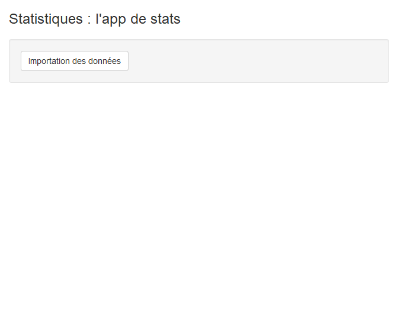

# Partie2

# Partie3

Comme Shiny oblige à avoir le server et l’UI dans le même Chunk, on va donc devoir détailler ici présent le code afin de le rendre le plus explicite possible.

##Présentation Shiny est un framework web pour le développement d’applications Web. Il est gratuit et open source et est développé par RStudio.

Quel est le but de R shiny ? Shiny a été créé afin de proposer une solution interactive aux utilisateurs de R.

Qu’est-ce que signifie exactement ce côté “interactif” et non statique ? Tout simplement, Shiny permet de modifier les bases de données en temps réel, permettant d’utiliser et réutiliser d’autres bases de données.

Comment peux-t-on facilement comprendre la structure de R Shiny ? R Shiny est composé de deux parties principales, qui peuvent être stockées dans deux fichiers distincts. Cela n’est donc pas le cas dans mon document !

La 1ere partie est l’interface UI , ou l’interface utilisateur, qui permet de stocker les choix par défaut de l’utilisateur. En effet , l’utilisateur sélectionne des variables via son menu déroulant.

La deuxième partie de l’application Shiny, est le back-end, càdire qu’il s’agit d’une partie qui est conçue pour accueillir tout les calculs de tests statistiques, la génération de graphiques. Cette partie peut peut être écrite entièrement dans le code R.

# Premièreétape

#1.PartieUI En effet, notamment, la partie UI permet de mettre en place l’interface graphique, et par là d’obtenir les choix de l’utilisateur.

#I.UI

La fonction shiny::fluidPage() crée une mise en page fluide pour une application Shiny, permettant aux éléments de s’ajuster dynamiquement à la taille de la fenêtre du navigateur.

Ainsi, elle sert de conteneur principal pour organiser divers composants de l’interface utilisateur tels que les titres, les barres latérales, les panneaux principaux, les graphiques et les tableaux.

De plus, elle facilite également l’utilisation de grilles et de conteneurs pour structurer l’agencement des éléments de manière intuitive. En résumé, fluidPage() est essentielle pour concevoir des interfaces utilisateur flexibles et adaptatives dans les applications Shiny.

#2.Titres.

Le titre est d’emblée mis en place grâce à Titlepanel.

Par ailleurs, il me semble important de souligner que j’ai utilisé également la version Javascript de Rshiny, shinyjs.

sidebarLayout crée une mise en page avec une barre latérale et une zone principale dans votre application Shiny.

Afin de recueillir les entrées des utilisateurs, par le biais de bouton ou de menu déroulant, j’utilise la fonction shiny qui s’appelle sidebarPanel, et qui est essentielle étant donnée qu’elle permet de mettre en place les choix .Elle permet de saisir les paramètres de nos tests statistiques.

Par exemple , dans ce sidebarpanel, on va pouvoir mettre en place le bouton d’importation qui permet de charger la base de donnée.  
Ainsi, par exemple dans ce menu déroulant, on va pouvoir ajouter une Introbox, qui va permettre d’intégrer les étapes de tutoriel interactif. (à voir si je réussis à l’ajouter)

Par ailleurs, chacun de ces boutons a comme argument la variable qui permettra par la suite au “server” de faire les calculs.

```r
# titlepanel permet de créer le titre de l'application
    shiny::titlePanel(shiny::tags$h3("Statistiques : l'app de  stats", windowTitle = "Statistiques : l'app des tests stats")),
    shiny::titlePanel(shiny::tags$h5(

    )
    ),
    # Je charge la librairie javscript de Shiny
    shinyjs::useShinyjs(),

    # Met en place la barre latérale qui permet de proposer de charger le Fichier
    shiny::sidebarLayout(
      shiny::sidebarPanel(
        # shiny::fileInput("file", "Upload a file"),

        shiny::actionButton("launch_modal", "Importation des données"),

        # Je mets en place le menu déroulant pour choisir la varaible expliquéeY
        rintrojs::introBox(
          shiny::uiOutput("expliquéeY_var_dropdown"),
          data.step = 3,
          data.intro = "Choose the expliquéeY variable from this dropdown."
        ),

        # Mettre le texte en-dessous
        rintrojs::introBox(
          shiny::textOutput("expliquéeY_var_text"),
          data.step = 4,
          data.intro = "Cela est la variable expliquéeY"
        ),

        # Menu déroulant pour choisir la variable explicativeX
        rintrojs::introBox(
          shiny::uiOutput("explicativeX_var_dropdown"),
          data.step = 5,
          data.intro = "Choisit la variable explicativeX X "
        ),
    rintrojs::introjsUI(),
```

3. Créer la console principale

Cette fonction mainpanel définit la zone principale de l’interface utilisateur de l’application Shiny, où les résultats et les visualisations seront affichés.

fluidRow organise le contenu en une ligne fluide et réactive, permettant aux éléments internes de s’ajuster automatiquement à la taille de la fenêtre du navigateur

```r
Afficher les données importées de manière interactive (maxium 12 colonnes)
      shiny::mainPanel(
        shiny::fluidRow(
          shiny::column(width = 12, DT::dataTableOutput("dataTable")),
          shiny::column(width = 12, shiny::plotOutput("expliquéeY_var_histogramme"))
        ),#Permet d'afficher également  le graphique d'histogrammeme, qui est chargé dans la partie Server.
      )
    )
  )
}



# Créer un graphique d'histogrammeme pour la variable dépendante
```

# Serveur

La fonction appServer est constituée essentiellement de code R, excepté certaine fonction pour les graphiques, souvent commençant par render.Ainsi, elle correspond à la partie serveur de shiny. Elle permet comme indiqué en introduction de se concentrer sur les calculs complexes ; et donc d’“implémenter” les fonctions de la variable UI.

1. Boucle if-else et création d’un programme et de messages

Cette fonction prend un jeu de données en entrée et le transforme en un tableau interactif grâce à DT::datatable, facilitant ainsi la visualisation des données dans l’application. determine_expliquéeY_variable :

Elle évalue la variable expliquéeY pour déterminer son type (numérique ou catégorique). Si numérique, elle effectue un test de normalité de Shapiro-Wilk et indique si l’hypothèse de normalité est vérifiée ou violée. Pour les variables catégoriques/caractères , elle identifie si elles sont binaires ou multinomiales. On peut souligner notamment que le type “caractère” doit être présent pour que les boucles fonctionnent.

Ainsi, cette fonction permet d’afficher des messages liées aux types. Toutefois, une deuxième fonction est mise en place par la suite afin de charger dans un vecteur de caractéristique le type de variable.

Cette caractérisation est la base, in fine, de la bonne adéquation de nos tests statistiques aux variables concernées. Certains détails ont été mis en commentaires. Ainsi , toute nos variables peuvent suivre une loi normale, soit pas. Ensuite, nos variables peuvent être de type quantitatif, binaire, voire catégorielle. Ainsi, cela va particulièrement influencé le choix du test statistique.

```r
#Partie 1 : tentons de déterminer automatiquement,après sélections de variables, le type.

# Afficher un tableau de données
app_server <- function(input, output, session) {
display_data_table <- function(data) {
  DT::datatable(data)
}


# Etape 1 : déterminer le type de variable  et afficher une phrase sur l'interface (après mise à jour dans l'UI)
#le type de la variable expliquéeY afin d'appliquer le test statistique adapté.

determine_expliquéeY_variable <- function(expliquéeY_var) {
  # Vérifions d'abord si la variable est numérique.
  if (is.numeric(expliquéeY_var)) {
    # Vérifions si elle suit une loi Normale.
    shapiro_test <- stats::shapiro.test(expliquéeY_var)

    # Or si pvalue<0,05 du test de Shapiro, cela  montre du coup qu'on a une normalité des résidus.
    if (shapiro_test$p.value < 0.05) {
      "L'hypothèse de normalité est violée"
    } else {
      "L'hypothèse de normalité est vérifiée"
    }
  } else if (is.character(expliquéeY_var)) {
    # Classer si la variable Y est binaire, ou bien ordinal/nominal
    unique_values <- length(unique(expliquéeY_var))
    if (unique_values == 2) {
      "La variable expliquéeY sélectionnée est binaire"
    } else if (unique_values > 2) {
      "La variable sélectionnée Y est multinomiale"
    } else {
      "La variable sélectionnée Y a des données invalides"
    }
  } else {
    "La variable sélectionnée n'est ni numérique ni caractère. "
  }
}

# 2 : Déterminer et afficher le type de la variable explicativeX Y

determine_explicativeX_variable <- function(explicativeX_var) {
  # Vérifie et affiche  si la variable explicativeX X sélectionnée est numérique ou pas .
  if (is.numeric(explicativeX_var)) {
    "La variable explicativeX sélectionnée est numérique."
  } else if (is.numeric(explicativeX_var)) {
  # Calcule le nombre d'éléments distincts afin de mieux calsser la variable.
    unique_values <- length(unique(explicativeX_var))
    if (unique_values == 2) {
      "La variable explicativeX sélectionnée est dichotomique."
    } else if (unique_values > 2) {
      "La variable explicativeX sélectionnée est catégorielle."
    } else {
      "La varaible dépendante a des données invalides"
    }
  } else {
    "La variable sélectionnée n'est ni numérique , ni une suite de caractères. "
  }
}
```

2.Associer le type de variables et le bon test statistique

Ainsi, on peut créer une fonction de statistique.Celle-ci va notamment associer le test adéquat aux types de variables rencontrés, suivant le type de la variable.

Cela est effectuée grâce à des if-else, et également à return.

```r
if (expliquéeY_var_caractéristique == "L'hypothèse de normalité est violée") {
    if (explicativeX_var_caractéristique == "continue") {
      return("Coeff de corrélation de Spearman")
    } else if (explicativeX_var_caractéristique == "unique") {
      return("Test du signe")
    } else if (explicativeX_var_caractéristique == "catégorielle") {
      return(c(
        "Wilcoxon test",
        "Mann-Whitney U test 2 (non apparié)"
      ))
    } else if (explicativeX_var_caractéristique == "catégorielle") {
      return(c(
        # "Test d'ANOVA apparié",
        "Kruskal-Wallis test 1 (explicativeX)"
      ))
    }
  } else if (expliquéeY_var_caractéristique == "L'hypothèse de normalité est vérifiée") {
    if (explicativeX_var_caractéristique == "continue") {
      return("Coeff de corrélation de Pearson")
    } else if (explicativeX_var_caractéristique == "unique") {
      return("Tstudent 1 echantillon")
    } else if (explicativeX_var_caractéristique == "catégorielle") {
      return(c("explicativeX samples t-test (non apparié)", "T-test (test apparié)"))
    } else if (explicativeX_var_caractéristique == "catégorielle") {
      return(c("One-way ANOVA (unpaired)"
               # "analyse de la variance à mesures répétées (appariée)"
      ))
    } #Mettons en place les tests également pour les régresions logistiques.
  } else if (expliquéeY_var_caractéristique == "binaire") {
    if (explicativeX_var_caractéristique == "unique") {
      return("Test du khi carre d'adequation")
    } else if (explicativeX_var_caractéristique == "catégorielle") {
      return(c("Test de McNemar (apparié)", "Chi carré test d'indépendance  avec le test de Fisher (non apparié)"))
    #Test de McNemar : permet de vérifier si les proportions entre les deux "catégories" sont significativement différentes ou non.
    } else if (explicativeX_var_caractéristique == "catégorielle & unpaired") {
      return("Test du Chi Carré d'indépendance  et test de Fischer non apparié")
    } else if (explicativeX_var_caractéristique == "catégorielle") {
      return(c(
        "Cochran's Q test "
        # "Cochran's Q test (paired)"
      ))
    }
```

## Tests

##3. Calculer les tests statistiques.

Afin de pouvoir calculer les test statistiques, il ne faut surtout pas oublier de charger tout les packages disponibles.

L’association du test et son exécution est symbolisée par switch(). La fonction switch(test_name, …) choisit et exécute un test statistique spécifique basé sur la valeur de la variable test_name que l’on a mis en place auparavant.

```r
#Calculons les tests statistiques avec une fonction de débug.


  result <- tryCatch(
    {
      switch(test_name,
             "Test du signe" = DescTools::SignTest(x = data[[expliquéeY_var]], mu = mu, alternative = "two.sided"),
             "Wilcoxon test" = stats::wilcox.test(data[[expliquéeY_var]] ~ data[[explicativeX_var]], data, paired = TRUE, alternative = "two.sided"),
             "Mann-Whitney U test 2 (non apparié)" = {
               unique_values <- unique(data[[explicativeX_var]])
               groupee1 <- data[data[[explicativeX_var]] == unique_values[1], expliquéeY_var]
               groupee2 <- data[data[[explicativeX_var]] == unique_values[2], expliquéeY_var]
               stats::wilcox.test(groupee1, groupee2, paired = FALSE, alternative = "two.sided", conf.int = TRUE)
             },
             "Kruskal-Wallis test 1 (explicativeX)" = stats::kruskal.test(data[[expliquéeY_var]] ~ data[[explicativeX_var]], data),
             "Tstudent 1 echantillon" = stats::t.test(data[[expliquéeY_var]], mu = mu, alternative = "two.sided"),
             "T-test (test apparié)" = stats::t.test(data[[expliquéeY_var]] ~ data[[explicativeX_var]], data, paired = TRUE, alternative = "two.sided", var.equal = FALSE),
             "explicativeX samples t-test (non apparié)" = {
               data[[explicativeX_var]] <- as.factor(data[[explicativeX_var]])
               if (length(levels(data[[explicativeX_var]])) != 2) stop("The explicativeX variable must have exactly two levels for an explicativeX t-test.")
               part_one <- stats::t.test(data[[expliquéeY_var]] ~ data[[explicativeX_var]], data, paired = FALSE, alternative = "two.sided", var.equal = FALSE)

               formula <- stats::as.formula(paste(substitute(expliquéeY_var), "~", substitute(explicativeX_var))) ## formula working example!
               part_two <- rstatix::cohens_d(data, formula,
                                             var.equal = TRUE)

               c(part_one, part_two)

             },
             # "analyse de la variance à mesures répétées (appariée)" = perform_repeated_measures_anova(data, expliquéeY_var, identifier_var, explicativeX_var),
             "One-way ANOVA (unpaired)" = {
               data[[explicativeX_var]] <- as.factor(data[[explicativeX_var]])
               res.aov <- stats::aov(data[[expliquéeY_var]] ~ data[[explicativeX_var]])
               summary(res.aov)
             },
             "CTest du khi carré d'adéquation" = {
               table_var <- table(data[[expliquéeY_var]], useNA = "no")
               reference_value <- if (explicativeX_var == "reference value") input_mean else max(table_var) / sum(table_var)
               stats::chisq.test(table_var, p = c(1 - reference_value, reference_value))
             },
             " test de McNemar (appareillé)" = { ## Error: Error in exact2x2::exact2x2(groupee_matrix, paired = TRUE, midp = TRUE): 'x' must have at least 2 rows and columns
               unique_values <- unique(data[[explicativeX_var]])
               groupee1 <- data[data[[explicativeX_var]] == unique_values[1], expliquéeY_var]
               groupee2 <- data[data[[explicativeX_var]] == unique_values[2], expliquéeY_var]
               groupee_matrix <- table(groupe1, groupe2)
               exact2x2::exact2x2(groupe_matrix, paired = TRUE, midp = TRUE)
             },#Test sur donnée nominale dichtomoique
             "Test du Chi-carré d'indépendance et test exact de Fisher (non apparié)" = stats::chisq.test(data[[expliquéeY_var]], data[[explicativeX_var]]),
             "Bhapkar's Test" = {
               unique_values <- unique(data[[explicativeX_var]])
               groupee1 <- data[data[[explicativeX_var]] == unique_values[1], expliquéeY_var]
               groupee2 <- data[data[[explicativeX_var]] == unique_values[2], expliquéeY_var]
               irr::bhapkar(cbind(groupe1, groupe2))
             },
             "Test des rangs signés de Wilcoxon II (appareillé" = {
               data[[expliquéeY_var]] <- as.numeric(as.factor(data[[expliquéeY_var]]))
               stats::wilcox.test(data[[expliquéeY_var]], paired = TRUE)
             },
             "Coeff de corrélation de Pearson" = stats::cor(data[[expliquéeY_var]], data[[explicativeX_var]], method = "pearson"),
             "Coeff de corrélation de Spearman" = stats::cor(data[[expliquéeY_var]], data[[explicativeX_var]], method = "spearman"),
             "Cochran's Q Test (paired)" = {
             data[[expliquéeY_var]] <- as.factor(data[[expliquéeY_var]])
             data[[explicativeX_var]] <- as.factor(data[[explicativeX_var]])
             rstatix::cochran_qtest(data[[expliquéeY_var]] ~ data[[explicativeX_var]] | data[[identifier_var]], data)
             },
             "Test exact de Fischer" = {
               data[[expliquéeY_var]] <- as.factor(data[[expliquéeY_var]])
               data[[explicativeX_var]] <- as.factor(data[[explicativeX_var]])
               stats::fisher.test(data[[expliquéeY_var]], data[[explicativeX_var]])
             },
             #Partie de tests non paramétrique  :
             "Test d'ANOVA apparié" = {
              data[[expliquéeY_var]] <- as.numeric(data[[expliquéeY_var]])
             data[[explicativeX_var]] <- as.factor(data[[explicativeX_var]])
             message(identifier_var)
             formula <- stats::as.formula(paste(substitute(expliquéeY_var), "~", substitute(explicativeX_var), "|", substitute(identifier_var)))
             stats::friedman.test(substitute(expliquéeY_var) ~ substitute(explicativeX_var) | substitute(identifier_var), data)
             stats::friedman.test(formula, data)
             },
             "Friedman's ANOVA II (paired)" = {


                message(expliquéeY_var)

                message(deparse(expliquéeY_var))
                message(substitute(expliquéeY_var))
                message(deparse(substitute(expliquéeY_var)))

                perform_friedman_test_now(data, substitute(expliquéeY_var), substitute(explicativeX_var), substitute(identifier_var))
                   data[[expliquéeY_var]] <- as.numeric(data[[expliquéeY_var]])
                   data[[explicativeX_var]] <- as.factor(data[[explicativeX_var]])
```

#4.Implémenter les éléments de l’interface graphique.

Toutefois, il faut notamment souligner qu’il est nécessaire d’implémenter dans Server certains éléments de l’interface graphique. Par exemple, rendre réactif le menu déroulant des varaibles se déroule dans la partie server. Evidemment, il est important d’exporter les résultats.

```r
  output$identifier_dropdown <- shiny::renderUI({
    shiny::req(sdata())
    shinyWidgets::pickerInput("identifier_var", "Choisir la variable identifiée", choices = colnames(sdata()))
  })

  # Menu déroulant des variables expliquéeYs
  output$expliquéeY_var_text <- shiny::renderText({
    shiny::req(input$expliquéeY_var)
    determine_expliquéeY_variable(sdata()[, input$expliquéeY_var])
  })

  # Texte additionnel pour la variable explicativeX.
  output$explicativeX_var_text <- shiny::renderText({
    shiny::req(input$explicativeX_var)

    if (input$explicativeX_var %in% colnames(sdata())) {
      determine_explicativeX_variable(sdata()[, input$explicativeX_var])
    }
  })

  # Nouveau menu déroulant pour sélectionner le test statistique.
  output$statistical_test_dropdown <- shiny::renderUI({
    shiny::req(input$expliquéeY_var, input$explicativeX_var)

    if (input$explicativeX_var == "reference value") {
      explicativeX_var <- "valeur de référence"
    } else {
      explicativeX_var <- sdata()[, input$explicativeX_var]
    }
    test <- SélectionTestStatistiques(sdata()[, input$expliquéeY_var], explicativeX_var)
    test_options <- c(test)
    shinyWidgets::pickerInput("statistical_test", "Choose statistical test", choices = test_options)
  })

  # Afficher l'histogramme de la variable Y sélectionnée.
output$expliquéeY_var_histogramme <- shiny::renderPlot({
    shiny::req(sdata(), input$expliquéeY_var)
    créer_expliquéeY_variable_histogramme(sdata()[, input$expliquéeY_var])
})

  # 4.Exporter les tests statistiques
output$test_report <- shiny::renderPrint({
  result <- perform_statistical_test(sdata(), input)
  if (!is.null(result)) result
})
}
```

# Commandes

L’intégration sous flexdashboard s’est révélée être plus simple que d’autres packages de template, car elle est dédiée aux rapports interactifs.

Ainsi, flexdashboard s’ajoute à Rmarkdown, et il a été plutôt simple à prendre en main. Ainsi, il existe uniquement des commandes de mise en page qui diffèrent de Rmarkdown: -la série de signes d’égalités ================ permettent notamment de créer une nouvelle page -les commentaires ##si storyboard accordés peuvente permettre de créer un menu déroulant à côté.

# Exporter

[output not shown]